# latihan 3

# PERSIAPAN DATA DAN PEMILIHAN LAG

```r
library("ggplot2")
library(readxl)
library(dplyr)
df <- read_excel("~/NewDelhi_Air_quality.xlsx")
names(df) <- tolower(names(df))

stopifnot(all(c("aqi","pm25") %in% names(df)))

data <- df %>%
  select(aqi, pm25) %>%
  rename(Y = aqi, X = pm25) %>%
  filter(!is.na(Y) & !is.na(X)) %>%
  arrange(row_number())

n <- nrow(data)
n_train <- floor(0.8 * n)

# bagi data
train <- data[1:n_train, ]
test  <- data[(n_train + 1):n, ]

y_train <- as.numeric(unlist(train$Y))
x_train <- as.numeric(unlist(train$X))
test_y  <- as.numeric(unlist(test$Y))
test_x  <- as.numeric(unlist(test$X))
h <- length(test_y)
```

```r
library("Metrics")
library("dLagM")
train_df <- data.frame(Yt = train$Y, Xt = train$X)

# Finite Distributed Lag Model (pilih q)
fdlm_out <- finiteDLMauto(Yt ~ Xt, data=train_df,
                          q.min=1, q.max=6,
                          model.type="dlm",
                          error.type="AIC",
                          trace=FALSE)

# ARDL (pilih p,q)
ardl_opt <- ardlBoundOrders(data=train_df, ic="AIC", formula=Yt ~ Xt)

# Simpan hasil lag optimum
q_opt <- if(!is.null(fdlm_out$q)) fdlm_out$q else 3
p_opt <- if(!is.null(ardl_opt$p)) as.numeric(ardl_opt$p) else 1
q_opt_ardl <- if(!is.null(ardl_opt$q)) as.numeric(ardl_opt$q) else 1

list(DLM_q = q_opt, ARDL_p = p_opt, ARDL_q = q_opt_ardl)
```

```
## $DLM_q
## [1] 6
##
## $ARDL_p
## [1] 15
##
## $ARDL_q
## [1] 15
```

Pada model DLM, lag optimum yang dipilih adalah 6, artinya pengaruh PM2.5 terhadap AQI masih bertahan hingga enam periode sebelumnya. Sedangkan pada model ARDL, lag optimum adalah 15 baik untuk AQI maupun PM2.5. Hal ini menunjukkan adanya dinamika jangka panjang, di mana kondisi AQI saat ini dipengaruhi oleh riwayat AQI dan PM2.5 hingga lima belas periode ke belakang.

# ESTIMASI MODEL

```r
# Model DLM
model_dlm <- dlm(formula = Yt ~ Xt, data=train_df, q=q_opt)

# Model Koyck
model_koyck <- koyckDlm(y = train_df$Yt, x = train_df$Xt, intercept = TRUE)

# Model ARDL
model_ardl <- ardlDlm(y = train_df$Yt, x = train_df$Xt, p=p_opt, q=q_opt_ardl)

summary(model_dlm)
```

```
##
## Call:
## lm(formula = as.formula(model.formula), data = design)
##
## Residuals:
##     Min      1Q  Median      3Q     Max
## -2.2139 -0.8627 -0.1935  0.8968  3.4352
##
## Coefficients:
##             Estimate Std. Error t value Pr(>|t|)
## (Intercept)  37.7848     2.0123  18.777   <2e-16 ***
## Xt.t        -11.6723     4.7598  -2.452   0.0183 *
## Xt.1         10.1808    10.1805   1.000   0.3229
## Xt.2         -5.7984    10.1956  -0.569   0.5725
## Xt.3          1.6388     5.6914   0.288   0.7748
## Xt.4          2.1590     3.1866   0.678   0.5017
## Xt.5         -0.1234     3.2521  -0.038   0.9699
## Xt.6         -1.5068     1.5790  -0.954   0.3453
## ---
## Signif. codes:  0 '***' 0.001 '**' 0.01 '*' 0.05 '.' 0.1 ' ' 1
##
## Residual standard error: 1.547 on 43 degrees of freedom
## Multiple R-squared:  0.577,  Adjusted R-squared:  0.5081
## F-statistic: 8.378 on 7 and 43 DF,  p-value: 1.994e-06
##
## AIC and BIC values for the model:
##        AIC      BIC
## 1 198.5178 215.9043
```

```r
summary(model_koyck)
```

```
##
## Call:
## "Y ~ (Intercept) + Y.1 + X.t"
##
## Residuals:
##      Min       1Q   Median       3Q      Max
## -2.19768 -0.57669 -0.03615  0.58158  2.18318
##
## Coefficients:
##             Estimate Std. Error t value Pr(>|t|)
## (Intercept)  4.54910    1.77579   2.562   0.0133 *
## Y.1          0.87326    0.05731  15.237   <2e-16 ***
## X.t         -0.56825    0.27658  -2.055   0.0449 *
## ---
## Signif. codes:  0 '***' 0.001 '**' 0.01 '*' 0.05 '.' 0.1 ' ' 1
##
## Residual standard error: 0.8986 on 53 degrees of freedom
## Multiple R-Squared: 0.8303,  Adjusted R-squared: 0.8239
## Wald test: 129.9 on 2 and 53 DF,  p-value: < 2.2e-16
##
## Diagnostic tests:
## NULL
##
##                             alpha       beta      phi
## Geometric coefficients:  35.89204 -0.5682546 0.873256
```

```r
summary(model_ardl)
```

```
##
## Time series regression with "ts" data:
## Start = 16, End = 57
##
## Call:
## dynlm(formula = as.formula(model.text), data = data, start = 1)
##
## Residuals:
##      Min       1Q   Median       3Q      Max
## -0.55322 -0.09398  0.01827  0.09262  0.64258
##
## Coefficients:
##              Estimate Std. Error t value Pr(>|t|)
## (Intercept)  57.47988   25.45695   2.258   0.0475 *
## X.t         -10.88093    4.30365  -2.528   0.0300 *
## X.1           5.47550    7.89060   0.694   0.5035
## X.2           4.38859    9.01694   0.487   0.6370
## X.3           4.83110    9.45128   0.511   0.6203
## X.4         -10.76401   10.14050  -1.061   0.3134
## X.5           6.34969   11.26689   0.564   0.5855
## X.6           6.52638    9.68442   0.674   0.5156
## X.7          -5.48248    9.17421  -0.598   0.5634
## X.8          -5.48865    9.04312  -0.607   0.5574
## X.9          -1.34017    8.79533  -0.152   0.8819
## X.10         -0.59322    8.42870  -0.070   0.9453
## X.11          2.35953    7.83935   0.301   0.7696
## X.12         -3.48658    5.67391  -0.614   0.5526
## X.13          1.88460    2.84217   0.663   0.5223
## X.14         -2.58972    2.58941  -1.000   0.3408
## X.15          0.32965    1.53070   0.215   0.8338
## Y.1          -0.07372    0.29063  -0.254   0.8049
## Y.2           0.37686    0.27681   1.361   0.2033
## Y.3           0.25965    0.30027   0.865   0.4075
## Y.4          -0.16241    0.27015  -0.601   0.5611
## Y.5           0.04272    0.25911   0.165   0.8723
## Y.6          -0.24626    0.26293  -0.937   0.3710
## Y.7           0.08739    0.26391   0.331   0.7474
## Y.8           0.10943    0.24432   0.448   0.6638
## Y.9          -0.18826    0.23669  -0.795   0.4449
## Y.10         -0.43768    0.24998  -1.751   0.1105
## Y.11         -0.27433    0.28280  -0.970   0.3549
## Y.12          0.25544    0.27398   0.932   0.3731
## Y.13          0.18845    0.29028   0.649   0.5308
## Y.14         -0.07574    0.30494  -0.248   0.8089
## Y.15         -0.33895    0.22452  -1.510   0.1621
## ---
## Signif. codes:  0 '***' 0.001 '**' 0.01 '*' 0.05 '.' 0.1 ' ' 1
##
## Residual standard error: 0.5025 on 10 degrees of freedom
## Multiple R-squared:  0.9865, Adjusted R-squared:  0.9445
## F-statistic:  23.5 on 31 and 10 DF,  p-value: 5.198e-06
```

Koyck menekankan hubungan dinamis sederhana: AQI sangat dipengaruhi oleh nilai sebelumnya (persistensi tinggi, φ = 0.87).

```r
# fitted values dari masing-masing model
fit_dlm   <- fitted(model_dlm)
```

```
##        1        2        3        4        5        6        7        8
## 26.29051 24.19350 22.40348 23.72382 23.63953 26.56466 28.73242 29.06563
##        9       10       11       12       13       14       15       16
## 29.85435 29.62890 29.04354 28.75054 29.20275 28.79736 28.76520 28.83105
##       17       18       19       20       21       22       23       24
## 28.71417 28.63336 28.15504 27.91307 28.19707 28.42245 28.60136 29.04912
##       25       26       27       28       29       30       31       32
## 28.56481 28.50134 28.28832 28.37811 28.38467 28.34809 27.35740 26.85105
##       33       34       35       36       37       38       39       40
## 26.28561 26.05948 26.21386 26.18306 25.79998 25.87109 25.76851 25.62502
##       41       42       43       44       45       46       47       48
## 26.12901 25.91438 26.00938 25.93984 26.28635 26.93856 27.78542 27.00630
##       49       50       51
## 27.31968 26.75133 25.26647
```

```r
fit_koyck <- fitted(model_koyck)
```

```
##        2        3        4        5        6        7        8        9
## 28.29714 27.17415 26.51282 25.25566 26.23506 26.25804 26.19768 24.25250
##       10       11       12       13       14       15       16       17
## 23.22660 24.03789 25.02233 26.06836 27.02628 28.83060 28.89318 28.94121
##       18       19       20       21       22       23       24       25
## 28.94535 28.07014 27.18017 27.16633 27.15768 27.14237 27.12382 27.08863
##       26       27       28       29       30       31       32       33
## 27.05391 27.92464 28.81682 30.58059 30.60403 31.47268 31.46436 30.58237
##       34       35       36       37       38       39       40       41
## 30.58433 29.71293 29.70607 28.77701 26.96237 26.03038 25.11935 25.10304
##       42       43       44       45       46       47       48       49
## 24.21345 24.18041 25.03657 25.03574 25.03392 25.92430 25.92887 26.80627
##       50       51       52       53       54       55       56       57
## 26.80851 26.82921 26.87938 27.82617 27.83014 26.94938 26.93230 25.98654
```

```r
fit_ardl  <- fitted(model_ardl)
```

```
## Time Series:
## Start = 16
## End = 57
## Frequency = 1
##  [1] 28.91007 29.03747 28.13889 26.85541 27.09680 26.97587 26.94238 26.91132
##  [9] 27.18916 27.33015 27.99732 29.06250 30.35742 31.08551 31.90649 31.78923
## [17] 31.25616 31.08508 30.36722 29.92559 28.95091 27.02790 26.00394 24.59598
## [25] 24.69255 24.07411 24.55322 24.87922 25.04947 25.51546 25.49736 25.97556
## [33] 26.94450 27.10483 26.73020 27.51687 27.86891 27.98760 26.93218 26.71362
## [41] 26.22197 24.94360
```

```r
# buat vektor actual yang panjangnya sama
act_dlm   <- y_train[seq_along(fit_dlm)]
act_koyck <- y_train[seq_along(fit_koyck)]
act_ardl  <- y_train[seq_along(fit_ardl)]

# hitung akurasi
results <- data.frame(
  Model = c("DLM", "Koyck", "ARDL"),
  MAPE  = c(mape(act_dlm,   fit_dlm),
            mape(act_koyck, fit_koyck),
            mape(act_ardl,  fit_ardl)),
  MAE   = c(mae(act_dlm,   fit_dlm),
            mae(act_koyck, fit_koyck),
            mae(act_ardl,  fit_ardl)),
  MSE   = c(mean((act_dlm   - fit_dlm)^2),
            mean((act_koyck - fit_koyck)^2),
            mean((act_ardl  - fit_ardl)^2))
)

results <- results %>% arrange(MAPE)
print(results)
```

```
##   Model       MAPE       MAE        MSE
## 1 Koyck 0.00746650 0.2112964  0.1253425
## 2   DLM 0.07677119 2.0824658  7.0686352
## 3  ARDL 0.09817648 2.7455552 10.0360701
```

```r
cat("Model terbaik (berdasarkan data training) adalah",
    results$Model[1], "dengan MAPE =", round(results$MAPE[1],4), "\n")
```

```
## Model terbaik (berdasarkan data training) adalah Koyck dengan MAPE = 0.0075
```

Evaluasi model menunjukkan bahwa Koyck memiliki akurasi terbaik (MAPE = 0.0075) dengan kesalahan prediksi yang jauh lebih kecil dibandingkan DLM maupun ARDL. Hal ini menegaskan bahwa model Koyck lebih sesuai untuk menjelaskan hubungan AQI dengan PM2.5 pada data ini.

# VISUALISASI MODEL TERBAIK

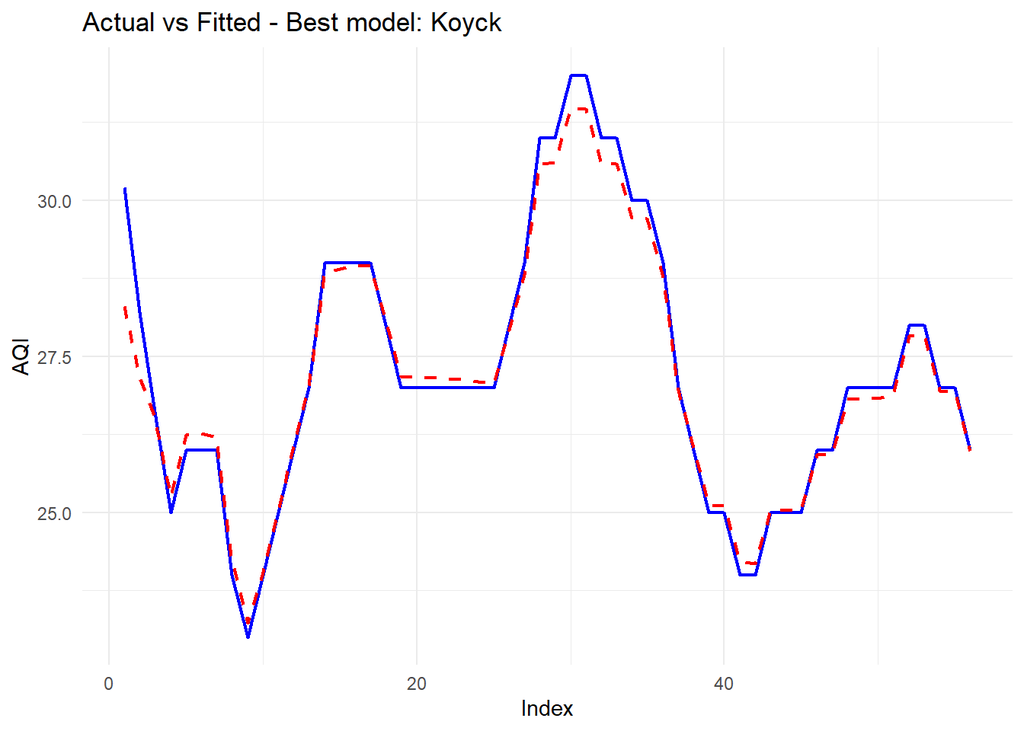

```r
best_model <- results$Model[1]

# ambil fitted & actual sesuai model terbaik
if(best_model == "DLM"){
  fit_best <- fit_dlm
  act_best <- act_dlm
} else if(best_model == "Koyck"){
  fit_best <- fit_koyck
  act_best <- act_koyck
} else {
  fit_best <- fit_ardl
  act_best <- act_ardl
}

df_plot <- data.frame(
  index = seq_along(act_best),
  Actual = act_best,
  Fitted = fit_best
)

ggplot(df_plot, aes(x = index)) +
  geom_line(aes(y = Actual), color = "blue", size = 0.8) +
  geom_line(aes(y = Fitted), color = "red", linetype = "dashed", size = 0.8) +
  labs(title = paste("Actual vs Fitted - Best model:", best_model),
       x = "Index", y = "AQI") +
  theme_minimal()
```

Grafik memperlihatkan garis biru (AQI aktual) dan garis merah putus‐putus (hasil prediksi model Koyck) yang hampir tumpang tindih. Pola naik–turunnya keduanya serupa, selisihnya kecil, sehingga model Koyck mampu memprediksi perubahan AQI dengan baik dan mengikuti tren data nyata secara konsisten.